# BMEG 601: Bayes Gaussian

David Klinke

2022-10-18

## Bayesian Inference for a Gaussian Mean

Last time, we estimated the value of a single parameter describing the probability of success using a single data point that summarized the results of a cohort and a binomial model. Today we are going to take a series of steps to estimate the value of two parameters that are associated with a Gaussian model for random variables. We are also going to perform a corollary of the *first goal* of a statistical analysis, which is to make a decision based on the confidence associated with estimated parameter.

The key mathematical difference between our discussion of estimating a binomial parameter and estimating the parameters associated with a Gaussian model is the mathematical relation for the likelihood. For a Gaussian model, that is the observations are distributed **normally**, the probability of observing an event $y$ is described by:
$$\begin{equation}
P(y|\mu, \sigma) = \frac{1}{\sqrt{2\pi} \sigma} \exp^{- \frac{1}{2 \sigma^2} (y - \mu)^2},
\end{equation}$$
where $\mu$ and $\sigma^2$ are the expected mean and variance of the observations, respectively.

Usually we have multiple observations of this random variable, such as $y_1, ..., y_n$ instead of a single observation. A common assumption of these observations is that they are independent and identically distributed samples of a random variable, which is abbreviated *i.i.d.*. This statement has two implications. First, the observations are independent means that the probability of one observation doesn’t depend on another observation. The probability of observing the set of observations is then the product of observing each individual event:
$$\begin{equation}
P(y_1, ... , y_n|\mu, \sigma) = P(y_1|\mu, \sigma) \times ... \times P(y_n|\mu, \sigma).
\end{equation}$$
Second, the observations are identically distributed means that we can use the same model, which here is a Gaussian model, to describe all the observations. The probability of observing the collective observations is then:
$$\begin{equation}
P(y_1, ... , y_n|\mu, \sigma) = \left(\frac{1}{\sqrt{2\pi} \sigma}\right)^n \exp^{- \frac{1}{2 \sigma^2} \sum_{i = 1}^n (y_i - \mu)^2}.
\end{equation}$$

Instead of summing up over all the observations each time we choose a new set of parameter values, we can simplify this expression to include just summary information about the sample. The sample information is the sample variance of the $y_i$’s, $s^2$ and the sample mean, $\bar{y}$. This simplified expression is then:
$$\begin{equation}
P(y_1, ... , y_n|\mu, \sigma) = \left(\frac{1}{\sqrt{2\pi} \sigma}\right)^n \exp^{- \frac{1}{2 \sigma^2} \left[(n - 1)s^2 + n(\bar{y} - \mu)^2 \right]}. \label{eqn1}
\end{equation}$$
where
$$\begin{equation}
s^2 = \frac{1}{n - 1} \sum_{i=1}^{n} (y_i - \bar{y})^2 \textrm{ and } \bar{y} = \frac{1}{n} \sum_{i = 1}^{n} y_i
\end{equation}$$

### Estimating the mean when the measurement uncertainty is known

Let’s consider the following problem: You are the engineer responsible for quality standards at a cheese factory. You want the probability that a randomly chosen block of cheese labeled ``1 kg" is actually less than 1 kilogram (1000 grams) to be 1% or less. The weight (in grams) of blocks of cheese produced by the machine is normally distributed with a variance of $3^2$. The weights (in grams) of a sample of 20 blocks of cheese are:

```r
sample1 <- c(994 , 997 , 999 , 1003 , 994 , 998 , 1001 , 998 , 996 , 1002,
1004 , 995 , 994 , 995 , 998, 1001 , 995 , 1006 , 997 , 998)
show(sample1)
```

```
##  [1]  994  997  999 1003  994  998 1001  998  996 1002 1004  995  994  995  998
## [16] 1001  995 1006  997  998
```

You decide to use a discrete prior distribution for $\mu$ with the probabilities for each value equal to 0.05.

```r
Value <- seq(991, 1010, by = 1)
Prior <- rep(0.05, length(Value))
Init <- data.frame(Parameter = Value, Prior = Prior)
```

#### (a) Calculate the posterior probability distribution

Because we are assuming that we know the variance of the blocks of cheese produced by the machine, we have to estimate only the posterior distribution of the average block size, $\mu$. This also implies that all of the terms that don’t include $\mu$ are a constant and can come out of the *Evidence* integral. These terms then cancel with the ones in the *likelihood*, which simplifies to:
$$\begin{equation}
P(y_1, ... , y_n|\mu) \propto \exp^{- \frac{n(\bar{y} - \mu)^2}{2 \sigma^2}}
\end{equation}$$

```r
likelihood <- function(mu, ybar, sigma, n){
  res <- exp(- (n*(ybar - mu)^2)/(2*sigma^2))
  return(res)
}
yb <- mean(sample1)
n <- length(sample1)
likelihood.prior <- apply(Init, 1, function(x) likelihood(x['Parameter'], yb, 3, n) * x['Prior'])
show(likelihood.prior)
```

```
##  [1] 2.162549e-27 7.069409e-21 2.504387e-15 9.614374e-11 3.999832e-07
##  [6] 1.803282e-04 8.810215e-03 4.664560e-02 2.676307e-02 1.664035e-03
## [11] 1.121218e-05 8.186886e-09 6.478114e-13 5.554944e-18 5.161927e-24
## [16] 5.198107e-31 5.672568e-39 6.708344e-48 8.597103e-58 1.193961e-68
```

Here since the prior distribution for $\mu$ consists of $m$ discrete values, we can calculate the **evidence** using a sum:
$$\begin{equation}
P(data) = \sum_{\textrm{i = i}^{m} \theta} P(data | \theta_i) \cdot P(\theta_i)
\end{equation}$$

Calculating the evidence is where numerical integration comes into play. .

```r
Evidence <- sum(likelihood.prior)
Posterior <- likelihood.prior/Evidence
Posterior
```

```
##  [1] 2.572170e-26 8.408469e-20 2.978759e-14 1.143549e-09 4.757464e-06
##  [6] 2.144852e-03 1.047901e-01 5.548102e-01 3.183243e-01 1.979230e-02
## [11] 1.333594e-04 9.737613e-08 7.705174e-12 6.607139e-17 6.139679e-23
## [16] 6.182712e-30 6.747043e-38 7.979013e-47 1.022553e-56 1.420116e-67
```

Using the posterior, we can then plot our knowledge of the average size of the blocks of cheese.

```r
# where is maximum
Parameter.max <- Init$Parameter[which.max(Posterior)]
Parameter.max
```

```
## [1] 998
```

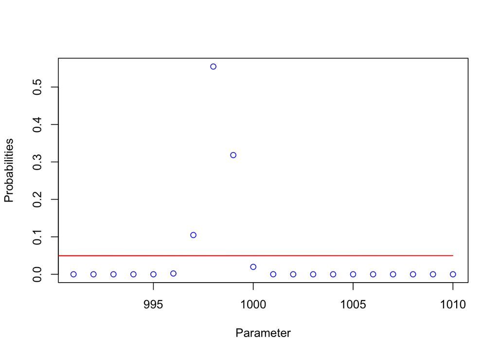

```r
plot(Init$Parameter, Posterior, type = "p", col = "blue", xlab = "Parameter", ylab = "Probabilities")
lines(c(0, Init$Parameter, 1), c(0, Init$Prior,0), col = "red")
```

#### (b) Calculate the posterior probability that $\mu < 1000$.

Given the posterior distribution, we can calculate this one-sided distribution by summing up all of the values for $\mu$ less than 1000.

```r
# let's determine 95% High Density Interval
idx <- 1
leftsum = 0
while (Init$Parameter[idx] < 1000){
  leftsum = leftsum + likelihood.prior[idx]/Evidence
  idx <- idx + 1
}
show(leftsum)
```

```
## [1] 0.9800742
```

#### (d) Additional Problems

- Calculate the two measures of central tendency: posterior median and posterior mean.
  $$\begin{equation}
  \int_0^{median} P(\theta|data) d\theta = 0.5\\
  mean = \int_{\textrm{all }\theta} \theta \cdot P(\theta|data) d\theta
  \end{equation}$$
- Calculate a measure of spread, such as the posterior variance.
  $$\begin{equation}
  \int_0^{median} P(\theta|data) d\theta = 0.5\\
  Var(\theta|data) = \int_{\textrm{all }\theta} (\theta - mean) \cdot P(\theta|data) d\theta
  \end{equation}$$

### Estimating the mean when the measurement uncertainty is unknown

Let’s consider the following problem: The current process used for making a polymer product has specifications that it contains 35% polymer. You are the engineer responsible for developing a modified process. You run the process on 10 batches and measure the percentage polymer in each batch. The values are:

```r
sample2 <- c(38.7, 40.4, 37.2, 36.6, 35.9, 34.7, 37.6, 35.1, 37.5, 35.6)
show(sample2)
```

```
##  [1] 38.7 40.4 37.2 36.6 35.9 34.7 37.6 35.1 37.5 35.6
```

Based on past experience, you know that the polymer in each batch is normally distributed but you don’t know the average value and standard deviation.

#### a) Find the joint posterior distribution

First, let’s use flat priors for both $\mu$ and $\sigma$. The prior for $\mu$ will be centered at the sample mean and standard deviation. The prior for $\sigma$ will start at small non-zero positive value (0.001) and end at $4 \cdot s$. A small non-zero positive value for $\sigma$ ensures that the calculated likelihood is defined. As these two unknown parameters are considered continuous random variables, we will have to use a numerical approach to do the integration. A trapezoidal approach will be used with an $n \times n$ grid.

```r
yb <- mean(sample2)
n2 <- length(sample2)
s2 <- sum((sample2 - yb)^2) / (n2 - 1)

n <- 100 # grid points
# mu is parameter 1 and sigma is parameter 2
h1 <- (8*s2)/n
h2 <- (4*s2 - 0.001)/n
mui <- seq(yb - 4*s2, yb + 4*s2, by = h1)
sgi <- seq(0.001, 4*s2, by = h2)
wij <- matrix(c(0.25, rep(0.5, n-1), 0.25, rep(c(0.5, rep(1, n-1), 0.5), n-1),
              0.25, rep(0.5, n-1), 0.25), nrow = n+1, ncol = n+1, byrow = TRUE)
mu.vec <- matrix(data = mui, nrow = n+1, ncol = n+1, byrow = FALSE)
# assuming prior values are equal to 1 - the particular value will cancel out
mu.prior <- matrix(data = 1, nrow = n+1, ncol = n+1, byrow = FALSE)

sg.vec <- matrix(data = sgi, nrow = n+1, ncol = n+1, byrow = TRUE)
sg.prior <- matrix(data = 1, nrow = n+1, ncol = n+1, byrow = TRUE)

theta.vec <- data.frame(mu = as.vector(mu.vec), sigma = as.vector(sg.vec), prior = as.vector(mu.prior)*as.vector(sg.prior))
```

We could plot the prior distribution, but this gives a rather uninteresting contour plot as all of the z-values are the same. Next we will calculate the likelihood for every combination of parameter values and do the integration to estimate the *Evidence*.

```r
likelihood <- function(mu, sigma, ybar, s, n){
  res <- (1/(2 * pi * sigma^2)^n) * exp(- ((n - 1)*s^2 + n*(ybar - mu)^2)/(2*sigma^2))
  return(res)
}

likelihood.prior.vec <- apply(theta.vec, 1, function(x) likelihood(x['mu'], x['sigma'], yb, s2, n2) * x['prior'])

Evidence <- h1*h2*sum(as.vector(wij)*likelihood.prior.vec)
```

Using the *Evidence* we can then plot the posterior distribution over the range of parameter values.

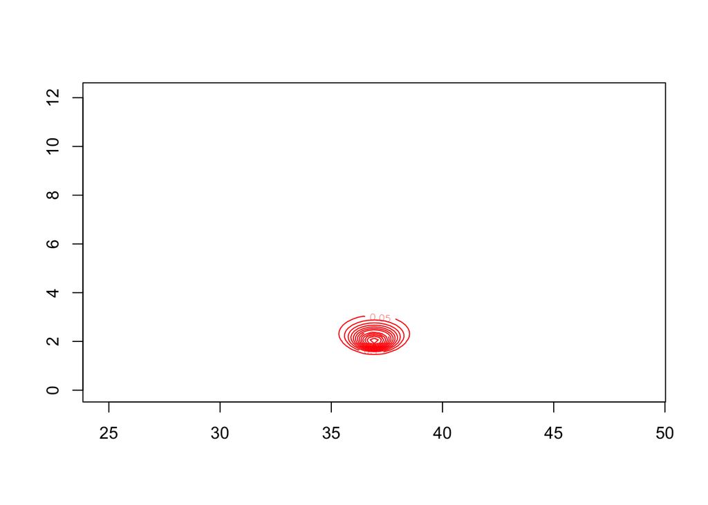

```r
Posterior <- likelihood.prior.vec/Evidence

contour(mui, sgi, matrix(Posterior, nrow = n+1, ncol = n+1, byrow = FALSE), col = "red")
```

```r
mu.prior <- matrix(data = dnorm(mui, mean = yb, sd = s2), nrow = n+1, ncol = n+1, byrow = FALSE)

sg.prior <- matrix(data = dgamma(sgi, shape = 2, scale = s2/2), nrow = n+1, ncol = n+1, byrow = TRUE)

theta.vec2 <- data.frame(mu = as.vector(mu.vec), sigma = as.vector(sg.vec), prior = as.vector(mu.prior)*as.vector(sg.prior))
```

Now we can plot the prior as it has changing values within the parameter space.

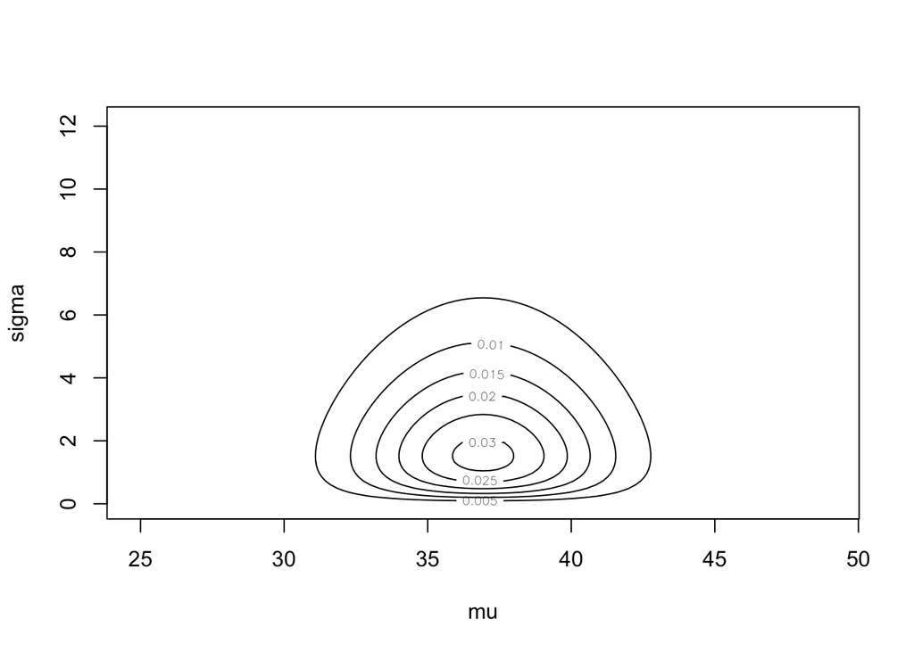

```r
contour(mui, sgi, mu.prior*sg.prior, xlab = "mu", ylab = "sigma")
```

Given this new prior, we can calculate the likelihood for every combination of parameters.

```r
likelihood.prior.vec2 <- apply(theta.vec2, 1, function(x) likelihood(x['mu'], x['sigma'], yb, s2, n2) * x['prior'])

Evidence2 <- h1*h2*sum(as.vector(wij)*likelihood.prior.vec2)
```

Using the *Evidence* we can then plot the posterior distribution over the range of parameter values.

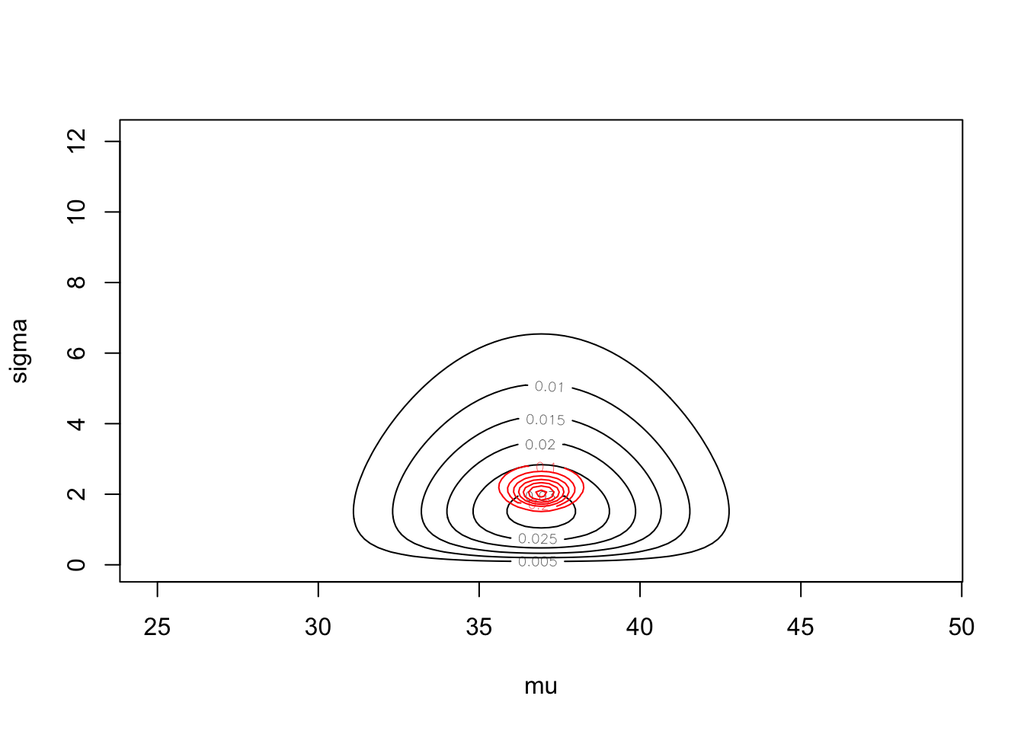

```r
Posterior2 <- likelihood.prior.vec2/Evidence2

contour(mui, sgi, mu.prior*sg.prior, xlab = "mu", ylab = "sigma")
contour(mui, sgi, matrix(Posterior2, nrow = n+1, ncol = n+1, byrow = FALSE), add = TRUE, col = "red")
```

As I mentioned in class, the data data that you have helps swamp the prior. Which means that the particular shape of the prior may not matter very much. What is important is that the particular values that end up having the high density region of the posterior must have a non-zero chance of being selected. That is they can’t have zero value for the prior. You can check this by comparing the posterior to the prior distributions. If the posterior seems to reside near the edge where the prior goes to zero, it might be good to redo the analysis and move the prior so that the posterior isn’t right at the edge. Here in this figure, we can see that the posterior is centered in the middle of the prior, so our selection of prior was appropriate.

#### b) Decision making using the posterior distribution.

The process manager wants to know if the modified process increases the mean yield. Using a 5% chance that you are not correct, can you claim that the modified process increases the yield?

To answer this question, we can integrate the posterior distribution for all values of $\sigma$ and values for $\mu$ greater than 35. To say that the modified process has increased the yield, the remaining area of the posterior distribution should be less than 5%. This question is related to one-sided hypothesis testing in the context of conventional null hypothesis significant tests.

```r
# Making sure that the posterior sums to 1
h1*h2*sum(Posterior2)
```

```
## [1] 1
```

```r
# Summing up the posterior with values of mu greater than 35
result <- h1*h2*sum(Posterior2[theta.vec2$mu > 35])
```

The calculations suggest that 0.5286513% of the posterior distribution falls with $\mu \le 35$. We can then conclude that the modified process has increased the percent of polymer in the product.

### Problems

1. In a research program on human health risk from recreational contact with water contaminated with pathogenic microbiological material, the National Institute of Water and Atmosphere (NIWA) in New Zealand instituted a study to determine the quality of water at a variety of catchment types. In a site identified as having a heavy environmental impact from seagulls and waterfowl, 116 one-liter water samples were acquired an analyzed. Out of those samples, 17 samples contained pathogenic *Giardia* cysts.
- What distribution can be used to describe the number of samples containing *Giardia* cysts?
- Let $\theta$ be the probability that a one-liter water sample from this type of site contains *Giardia* cysts. Use a uniform prior for $\theta$. Find the posterior distribution of $\theta$, given the data.
- Summarize the posterior distribution by its first two moments.
- Compare the posterior distribution in $\theta$ against a normal distribution parameterized by the first two moments. Quantitatively compare the distributions.
- Compute a 95% high density interval for $\theta$
2. An engineer takes a sample of 5 steel I beams from a batch, and measured the amount they sag under a standard load. The amounts in mm are: 5.19, 4.72, 4.81, 4.87, 4.88. It is known that the sag follows a normal distribution.
- Use a normal prior for $\mu$ and a flat prior for $\sigma$ informed by the sample mean and standard deviation. Find the posterior distribution of the parameters.
- For a batch of I beams to be acceptable, the mean sag under the standard load must be less than 5.20. Explicitly state your decision making criteria.
- Make a decision, assuming that you have a 5% chance of being wrong.